# Lecture 1

August 2022

## Technical details

## Who am I?

- Guillaume [gijom] Roussellet
- guillaume.roussellet@mcgill.ca
- Office BRONF 555.
- *My research*: Fixed Income, Credit Risk, Time Series Asset Pricing Models, Machine Learning, Financial Econometrics.
- *Preferred programming languages*: `R` (mostly) and `Python` (a bit less).

## What are we going to do?

- Intense training to learn the basics of code and data management.
- From here…

[figure not shown]

## What are we going to do?

- to there.

[figure not shown]

## What are we going to do?

- Lecture 1:
  - (a brief) History of computers.
  - Programming basics: classes.
  - Programming basics: loops and tests.
- Lecture 2:
  - Data management.
  - Plotting.
- Lecture 3:
  - Regression analysis.
  - Markdown for documents and presentations.

## Why Programming?

## How does a computer work?

- Assume you are opening an Excel spreadsheet. You double-click.
  - Commands are executed by you computer in the background.
  - Document opens and is stored temporarily in the **memory (RAM)**.
  - Excel is an **interface** allowing you to **communicate** with your computer and ask it to do computations for you.
  - Computations are performed by the **CPU** which is essentially a clock.
  - Once the **CPU** has finished, it sends back to the **RAM**.
  - Saving writes the **RAM** into the **Disk**.
  - Quitting erases the **RAM**.

## Why a coding class then?

- Computers are machines that speak a bunch of **languages**.
- They only do what you ask them to do.
- Plain vanilla stuff is already implemented, but you’ll have to do more by yourself!

\(\Longrightarrow\) **ENTERS PROGRAMMING!**

- We will learn the principles of communicating with your machine!
- That will avoid you being hostage of machines in the future.

[figure not shown]

## Why Python?

- Python is very versatile, and the community is strong.
- It’s easy to find answers when you’re having troubles.
- It’s **free**!
- Alternatives (for finance):
  - R (free, a good alternative!)
  - Matlab (expensive, for maths and finance)
  - SAS (expensive, data management)
  - Stata and EViews (expensive and weird)
  - C++ (free, hard)

## A foreword

- Coding is **hard**!
  - Best way to learn is to do **trial and error**.
  - Practice on simple examples at home!
- You should never say **it doesn’t work**.
  - You role is to understand what’s going wrong.
  - A computer is stupid, if your syntax and grammar are wrong, no room for interpretation.
  - Google is definitely your best friend for error messages.
- Useful resources: [Python Doc](https://docs.python.org/3/), [Stackoverflow](https://stackoverflow.com/), [collection of helps](https://www.fullstackpython.com/best-python-resources.html)

## Before we go

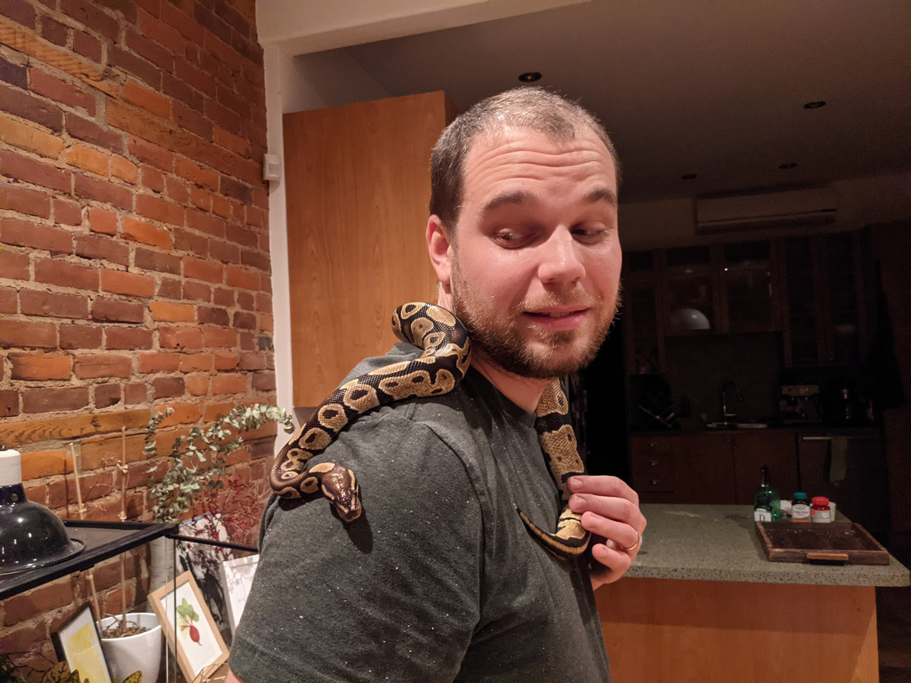

Me and my python pet Java

## Installing Python

## Requirements

- You need to install Python, and an interface to communicate with you computer in Python.
- Programming usually involves:
  - Writing code in an *editor* to obtain a **script**.
  - Compiling the **script** to obtain the results.
- Doing so is efficient because it allows you to see the complete structure of what you’re asking to the computer.
- There are many editors and compilers, but we’ll use a simple setup.
  - Our platform will be **Anaconda**.
  - We will use the editor **Spyder**.

## Anaconda

- Anaconda can be downloaded [on the anaconda website](https://www.anaconda.com/products/individual).
- Installation is standard and explained [here](https://docs.anaconda.com/anaconda/install/windows/) in case.
- Once this is done, run the Anaconda navigator:

[figure not shown]

Basic Anaconda Navigator

## Launching Spyder

[figure not shown]

Basic Anaconda Navigator

## Launching Spyder

[figure not shown]

Updating Spyder

## Launching Spyder

[figure not shown]

Spyder Interface

## The Spyder Interface

[figure not shown]

Spyder Interface

## The Spyder Interface

[figure not shown]

Spyder Interface

## The Spyder Interface

[figure not shown]

Spyder Interface

## How does Python work?

- Think about `Python` as a powerful calculator and much more from now on.
- Examples:
  - Difficult computations like \(\sqrt{\exp(1852)}\), or option greeks.
  - Data exploration (mean, stdev, correlations, etc).
  - Data transformation (cleaning, creating new variables).
  - Text scrapping.
  - Sending emails every hour to your teammates automatically.

## How does Python work?

- `Python` is *OpenSource* and there is a huge community.
- It includes so-called **libraries** that you can download.

Important coding principles:

- The community is smarter than me.
- If I have a problem, somebody had it before.
- I should use readily available libraries **as long as I understand what it does**.

Important libraries:

- Throughout the class we will use the same libraries over: `numpy` (matrix computation), `matplotlib` (charts), `pandas` (basic stats), `ScyPi` (complex mathematics).
- More info [here](https://analyticsindiamag.com/best-python-libraries-for-data-science-in-2021/).

## Beginning with Python

## First elements of syntax

- Creating a simple variable with `Python`:

```python
my_variable = 42
```

- `my_variable` is a number (integer).
- Once I send it to the console, it is in the memory and I can call it again.

```python
new_var = my_variable - 5
print(new_var)
```

```
## 37
```

- Variables are **erased from memory when I quit Spyder**, but the script lives on!

## Simple types of variables

- Many types of variables can be created.
- `float`: numbers with decimals

```python
my_float = 100.0
print(my_float)
```

```
## 100.0
```

- `string`: a chain of characters

```python
my_string = "I'll be back"
print(my_string)
```

```
## I'll be back
```

```python
print(my_string[0:7])
```

```
## I'll be
```

## Simple types of variables (c’td)

- `list`: can mix numbers and strings

```python
my_list = [42, "I'll be back", 100.0]
print(my_list)
```

```
## [42, "I'll be back", 100.0]
```

- We could also call the created variables:

```python
my_list_bis = [my_variable, my_string, my_float]
print(my_list_bis)
```

```
## [42, "I'll be back", 100.0]
```

- Checking if lists are the same:

```python
my_list_bis == my_list
```

```
## True
```

## Simple types of variables (c’td)

- `dictionaries`: a list of named elements (rather than numbered)

```python
my_dictionary = {}
my_dictionary['forty two'] = my_variable
my_dictionary['terminator'] = my_string
print(my_dictionary)
```

```
## {'forty two': 42, 'terminator': "I'll be back"}
```

- Calling elements of a dictionary:

```python
print(my_dictionary['terminator'])
```

```
## I'll be back
```

- Comparing with lists:

```python
# print(my_dictionary[0]) => Does not work
print(my_list[0])
```

```
## 42
```

## What have we learnt so far?

- Variables are easy to create, and they are in memory once created.
- Variables can have different **types** depending on their use.
- We can call elements of variables with the squared brackets.

**Caution!**

- First element is **always numbered 0**.

```python
print(my_list)
```

```
## [42, "I'll be back", 100.0]
```

```python
print(my_list[1])
```

```
## I'll be back
```

- Operations can be called on the fly on already created variables.

## More variable types?

- In our finance curriculum, we will have to play with matrices and vectors.
- This is allowed in `Python` with the `numpy` library.
- We need to tell our session that we want to use all the stuff located in `numpy`:

```python
import numpy as np
```

- We can construct vectors (succession of numbers):

```python
my_vector = np.array([1.5,2.3])
print(my_vector)
```

```
## [1.5 2.3]
```

- and matrices (tables of numbers):

```python
my_matrix = np.array([[1,2],[3,4]])
print(my_matrix)
```

```
## [[1 2]
##  [3 4]]
```

## Matrix manipulation

- Knowing the dimension of a matrix?

```python
print(my_matrix.shape)
```

```
## (2, 2)
```

- Matrix multiplication (please watch [this video](https://www.youtube.com/watch?v=XkY2DOUCWMU) if you don’t remember)

```python
my_multiplication = np.matmul(my_matrix, my_vector)
print(my_multiplication)
```

```
## [ 6.1 13.7]
```

- Matrix transpose (can use `.T` instead):

```python
print(my_matrix.transpose())
```

```
## [[1 3]
##  [2 4]]
```

## Create empty matrices

- Creating a matrix of zeros

```python
mat_zeros = np.zeros((2,10))
print([mat_zeros, mat_zeros.shape])
```

```
## [array([[0., 0., 0., 0., 0., 0., 0., 0., 0., 0.],
##        [0., 0., 0., 0., 0., 0., 0., 0., 0., 0.]]), (2, 10)]
```

- matrix of ones:

```python
mat_ones = np.ones((1,5))
print([mat_ones, mat_ones.shape])
```

```
## [array([[1., 1., 1., 1., 1.]]), (1, 5)]
```

- Identity matrix:

```python
mat_diag = np.eye(2) ; print(mat_diag)
```

```
## [[1. 0.]
##  [0. 1.]]
```

## Matrix simple operations

```python
mat_diag + 1; mat_diag - 1; mat_diag * 2; mat_diag/2
```

```
## array([[2., 1.],
##        [1., 2.]])
## array([[ 0., -1.],
##        [-1.,  0.]])
## array([[2., 0.],
##        [0., 2.]])
## array([[0.5, 0. ],
##        [0. , 0.5]])
```

```python
mat1 = np.ones((2,2)); mat2 = np.array([[1,2],[3,4]])
mat1 + mat2; mat1 - mat2; mat1 * mat2; mat1/mat2
```

```
## array([[2., 3.],
##        [4., 5.]])
## array([[ 0., -1.],
##        [-2., -3.]])
## array([[1., 2.],
##        [3., 4.]])
## array([[1.        , 0.5       ],
##        [0.33333333, 0.25      ]])
```

## What have we learnt so far?

- We can construct vectors and matrices with `numpy`.
- We can perform the standard computations calling `array.function`.
- Some specific objects can be constructed directly:
  - zeros with `np.zeros(nrow,ncol)`,
  - ones with `np.ones(nrow,ncol)`,
  - identity with `np.eye(nrow)`,
  - diagonal with `np.diag(number1, ..., number n)`.
- Operations are performed element by element.

**Caution!**

Remain careful about dimensions!

```python
mat_diag + mat_ones
```

```
## Error in py_call_impl(callable, dots$args, dots$keywords): ValueError: operands could not be broadcast together with shapes (2,2) (1,5)
##
## Detailed traceback:
##   File "<string>", line 1, in <module>
```

## Some practical examples:

- Evaluate and understand what the following expressions are producing. In case computation cannot be performed, explain why.

```python
2 ** 3 ; pow(2,3)
2 ** 3/4
np.ones([2,2]) @ np.array([[1,2],[3,4]])
[1,'1'] * [3, '4']

a = 4
b = 5
a -= 3 + b

['a', 'b', 'c', 'd'][2]
'Stonks only go up'[5:9]
['Stonks only go up'][5:9]

np.ones([1,5]) + np.diag([1,2])
```

- Create a \((2\times 2)\) matrix containing elements (1,2,3,4) starting filling columns. Invert it with the function `linalg.inv` of `numpy`.

## Best practices

## Commenting the code

[figure not shown]

**1. ALWAYS COMMENT YOUR CODE**

- Commenting allows your future self to understand and reuse the code.
- Commenting allows **others** to understand what you are doing.
- You’ll rapidly reach more than 1,000 lines of script.
- It’s more costly when you write it but it is **ESSENTIAL**.

## How do we comment and what does commented code look like?

- We can comment entire paragraphs with `""" comment """`.
- We can comment end of lines with `#`.

A typical script:

```python
""" 0. Import libraries """
import numpy as np

""" 1. Building the needed matrices. """
my_matrix = np.array([[1,3],[2,4]]) # This matrix is (2x2)
my_matrix2 = np.ones((2,5)) # This matrix is (2x5)

""" 2. Performing our operations """
result = np.matmul(my_matrix, my_matrix2)

# Once our result is computed, we can perform other operations
```

## Naming the variables

[figure not shown]

**2. CHOOSE EXPLICIT NAMES FOR VARIABLES**

- You won’t remember what `X9` is.
- So choose variable names that **makes sense** out of context.
- You can have them as long as you want.

Example:

```
matrix_example_for_Python_course = np.array()
```

**BE CAREFUL**

- `Python` is **case-sensitive**
- Variables `toto`, `Toto` and `toTo` are all different!

## Basic useful commands

## Programming 101.

- There are two basic types of operations that makes programming appealing.
  - **Tests**
  - **Loops**
- **Tests** allow for the programmer to verify whether a particular condition is met for any object, and apply an operation depending on the case.
  - For instance, you retrieve a lot of company balancesheet.
  - You want to know which company has leverage greater than a threshold.
- **Loops** recognize that your data may be large, and you have to perform similar operations row-by-row, or column-by-column.
  - Imagine you have 10,000 companies.
  - You want to perform the leverage test for each company.
- **Tests** are called with `if` and `else`.
- **loops** are called with `for` or `while`.

## `If` statements

- Let us consider `my_variable` which was equal to…?
- Let’s test where it is:

```python
my_bool = my_variable > 50 ; print(my_bool)
```

```
## False
```

```python
my_bool = my_variable <= 50 ; print(my_bool)
```

```
## True
```

```python
my_bool = my_variable == 50 ; print(my_bool)
```

```
## False
```

- `my_bool` is yet another type of object called **boolean**, which says `True` or `False`.
- `if` statements will create booleans to make a decision.

## `If` statements

- Let us make the computer print different messages whether `my_variable` is above 9,000.

```python
if my_variable > 9000:
  print("It's over 9,000!")
elif my_variable == 9000:
  print("It's exactly 9000")
else:
  print("I have to stop watching Dragon Ball.")
```

```
## I have to stop watching Dragon Ball.
```

- For a simple test, put `if [CONDITION]:` and go to the next line.
- `elif` is the combination of `else` and `if` to test a second condition.
- `else:` gathers all remaining cases.
- The space on lines after `if`, `elif` and `else` is called **indentation**

  **EXTREMELY IMPORTANT.**
- Code won’t run if you don’t put it.

## `If` statements

- You can test many types of conditions:
  - Equal: `==` (to not be mistaken with `=` which assigns a value)
  - Not equal: `!=`
  - Less than: `<`
  - Less or equal: `<=`
  - Greater than: `>`
  - Greater or equal: `>=`
- You can test joint conditions:
  - more than one conditions are met: `if a < 10 and a >= 5:`
  - at least one condition is met: `if a < 10 or a >= 5:`

## `If` statements

- You can nest conditions:

```python
a = 42
if a > 10:
  print("above ten")
  if a > 20:
    print("and also above twenty!")
  else:
    print("but not above twenty.")
```

```
## above ten
## and also above twenty!
```

- the `else` only concerns the second test. If I defined `a = 5`, what would happen?
- Every time you add a new `if` you need another indentation (won’t work if not anyway)
- This architecture will allow you to read easily scripts.

## `If` statements

[figure not shown]

## `for` loops

- `for` loops allow you to perform the same operation for each element of an object.
- It takes a starting and an ending value.

```python
""" Initializing our result vector """
dummy_greater = np.zeros((100,1)) # Dimension is (100x1)

""" Performing for loop """
for i in range(0,100):
  if a >= (i+1):
    dummy_greater[i] = 1
```

- What does this code do?
- `range(start,end)` consists in all integers from `start` to `end-1`.
- Don’t forget: first element of a vector is numbered 0.

## Customizing `for` loops

- You can loop on pretty much whatever you want, even strings

```python
Score_teams = {}
Score_teams["MTL"] = 4
Score_teams["VGK"] = 1

for names in Score_teams.keys():
  print(Score_teams[names])
```

```
## 4
## 1
```

- This is important since the structure of your data will matter.
- You can loop on variables in your data for instance.

## Exercise with `for` loops

- Assume you have a bond paying off semi-annually.
- Its cashflow is two dollars every payment period.
- Its last cashflow is $102
- Its maturity is five years.
- Assuming a year has 364 days, construct the vector of daily cashflows by completing the following code:

```python
# Constructing a vector of cashflows
Final_cashflow_vector = np.zeros((364 * 5))

# Complete the rest
```

## `while` loops

- `while` loops are a combination of `for` and `if`.
- They perform an operation while a certain condition is true.
- It is very useful for controlling your P&L for instance: while `gains` are below `threshold`, otherwise liquidate position.
- Syntax is similar to `for` and `if`:

```python
import random as rd

Gains = np.zeros(1)
count = 0
threshold = 10
while Gains[count] < threshold:
  heads_tails = rd.randint(0,1)

  if heads_tails == 1:
    Gains = np.append(Gains, Gains[count] + 1)
  else:
    Gains = np.append(Gains, Gains[count] - 1)
  count +=1 # same as count = count + 1
```

## `while` loops

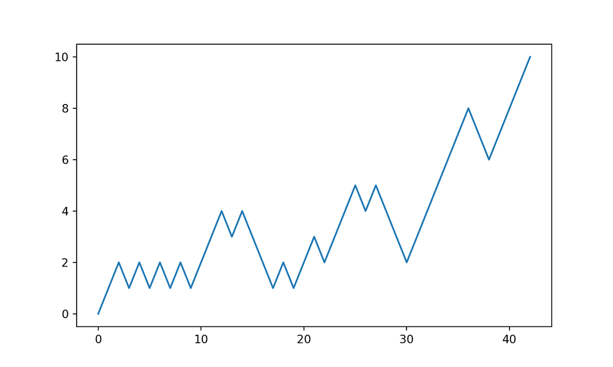

```python
import matplotlib.pyplot as plt

plt.plot(Gains)
```

## Getting help

- There are a lot of things you don’t know how to do in code.
- Resources: Google and `help`

```python
help(plt.plot)
```

[output not shown]

[output cut: 218 more lines]

```
##     ``'b'``          blue
##     ``'g'``          green
##     ``'r'``          red
##     ``'c'``          cyan
##     ``'m'``          magenta
##     ``'y'``          yellow
##     ``'k'``          black
##     ``'w'``          white
##     =============    ===============================
##
##     and the ``'CN'`` colors that index into the default property cycle.
##
##     If the color is the only part of the format string, you can
##     additionally use any  `matplotlib.colors` spec, e.g. full names
##     (``'green'``) or hex strings (``'#008000'``).
```

## Programming like a boss

## Going further: functions

- In your programming career, you will likely feel limited by standard `python` functions.
- Think about Excel: it computes sums and averages nicely, but doesn’t have stuff implemented:
  - Calculating distributions (histograms)
  - performing many linear regressions
  - implementing Black-Scholes on many options.
- You will need to *tune* your code to your particular aim.
  - **Case 1:** Somebody already coded that for you (library `blackscholesanalytics` for instance)
  - **Case 2:** The thing you want is not available.
- Python allows you to construct/modify `functions` that can perform any set of operations you want.

## functions: an example with options data

- I’m loading options data on a day (we’ll cover that next lecture).

```python
print(Option_data.columns)
```

```
## Index(['quote_date', 'underlying_symbol', 'root', 'expiry', 'strike', 'type',
##        'open_interest', 'total_volume', 'high', 'low', 'open', 'last',
##        'last_bid_price', 'last_ask_price', 'underlying_close', 'series_type',
##        'product_type'],
##       dtype='object')
```

```python
print(Option_data.shape)
```

```
## (228, 17)
```

## Reducing the data

```python
print(Option_data.head(5))
```

```
##    quote_date underlying_symbol  ... series_type product_type
## 0  1990-01-02              ^SPX  ...         NaN          NaN
## 1  1990-01-02              ^SPX  ...         NaN          NaN
## 2  1990-01-02              ^SPX  ...         NaN          NaN
## 3  1990-01-02              ^SPX  ...         NaN          NaN
## 4  1990-01-02              ^SPX  ...         NaN          NaN
##
## [5 rows x 17 columns]
```

```python
reduced_Option_data = Option_data[["quote_date", "strike",
  "expiry","type", "last_ask_price", "underlying_close"]]
print(reduced_Option_data)
```

```
##      quote_date  strike      expiry type  last_ask_price  underlying_close
## 0    1990-01-02   275.0  1990-03-17    C           86.88            359.69
## 1    1990-01-02   275.0  1990-03-17    P            0.94            359.69
## 2    1990-01-02   300.0  1990-03-17    C           62.75            359.69
## 3    1990-01-02   300.0  1990-03-17    P            1.38            359.69
## 4    1990-01-02   325.0  1990-03-17    C           39.75            359.69
## ..          ...     ...         ...  ...             ...               ...
## 223  1990-01-02   350.0  1990-12-22    P           16.00            359.69
## 224  1990-01-02   375.0  1990-12-22    C           19.13            359.69
## 225  1990-01-02   375.0  1990-12-22    P           26.13            359.69
## 226  1990-01-02   400.0  1990-12-22    C           10.13            359.69
## 227  1990-01-02   400.0  1990-12-22    P           40.00            359.69
##
## [228 rows x 6 columns]
```

## Function syntax

- Let us create a function that computes **moneyness**
- **Moneyness** is an indicator of whether options insure against probable events.
- It is roughly equal to `strike/underlying`.
- You need to do it for every option!

```python
def Compute_moneyness (strike, underlying):
  return strike/underlying

Compute_moneyness(reduced_Option_data["strike"][0],
                  reduced_Option_data["underlying_close"][0])
```

```
## 0.7645472490199895
```

- We could now apply our `Compute_moneyness` function to any option.
- We could also do a `for` loop to compute the moneyness of all options.

## Tuning the function

- Options are either in-the-money, at-the-money, or out-the-money.
  - For puts: ATM (1), ITM (>1), OTM (<1)
  - For calls: ATM (1), ITM (<1), OTM (>1)

```python
def Compute_moneyness (strike, underlying, opt_type):
  Moneyness = strike/underlying
  if Moneyness == 1:
    result = "ATM"
  elif Moneyness < 1:
    if opt_type == "P":
      result = "OTM"
    else:
      result = "ITM"
  else:
    if opt_type == "P":
      result = "ITM"
    else:
      result = "OTM"
  return result

Compute_moneyness(reduced_Option_data["strike"][0],
                  reduced_Option_data["underlying_close"][0], reduced_Option_data["type"][0])
```

```
## 'ITM'
```

## Functions

- Functions begin with `def`
- Then you define the name of the function
- You define the arguments of the function in `(argument)`, separated by commas.
- You send back the result with `return`.
- You can send back any type of object.
- The function is stored and you can call it whenever you want.

## Exercises

## Compute the price of a bond

- Discount rate is 5%.
- Bond pays annually a cashflow of $2.
- Bond has maturity 10 years. \[ P = \sum_{i=1}^T \frac{cp\times FV}{(1+r)^i} + \frac{FV}{(1+r)^T} \]

**Exercise:**

1. Represent cashflows and discount factors as vectors and use `np.matmult` to compute the price of the bond.
2. Construct a function that can price any bond, with arguments `coupon`, `FV`, `maturity` and `discount_rate`.
3. Considering that each discount rate can be different, construct a function that can accept a vector of discount rates.
4. Apply your functions on the original bond, on the same bond with coupon rates 1% to 10% by increments of 1pp.
5. Do the same if the discount rates are 1% for the one-year rate and increase by 25bps for each year of maturity.

## Appendix: Same things with `R`

## Basic objects

```r
x_int <- 12 # Integer
x_flo <- 1.5 # float
x_vec <- c(1,5,12) # vector of 3 elements
x_seq <- seq(0, 10, by = 0.5) # vector of all floats from 0 to 10 by step of 0.5
x_mat <- matrix(1:6, nrow = 2, ncol = 3) # matrix (2x3) filled by COLUMNS first

# Lists
x_lst <- list("a" = c(1:3), "b" = "toto"); print(x_lst)
```

```
## $a
## [1] 1 2 3
##
## $b
## [1] "toto"
```

```r
# Data frames
x_dfm <- data.frame("first_var" = c(5:8), "second_var" = c("a","b","c","d")); print(x_dfm)
```

```
##   first_var second_var
## 1         5          a
## 2         6          b
## 3         7          c
## 4         8          d
```

## Basic objects

- Careful! First element is numbered 1, not 0!

```r
# matrices
#---------
# Zeros:
x_zeros <- rep(0, 10); x_mat_zeros <- matrix(0, nrow = 2, ncol = 3)
# Ones: same principle replacing 0 by 1 in previous expressions

# Diagonal matrix
x_diag <- diag(1,10) # (10x10) identity matrix
# Multidimensional arrays
x_array <- array(0, dim = c(2,3,5)) # (2x3x5) array of numbers

# Transpose matrix
x_transpose <- t(x_mat) # (3x2) matrix
# Inverse matrix
x_inv <- solve(x_diag)
# Matrix multiplication
x_transpose %*% x_mat
```

```
##      [,1] [,2] [,3]
## [1,]    5   11   17
## [2,]   11   25   39
## [3,]   17   39   61
```

## Tests and loops

```r
# If tests
x <- 42
if (x > 10) {
  print("x > 10")
}
```

```
## [1] "x > 10"
```

```r
# Ifs can be called on the fly
my_vec <- c(-5:5)
print(my_vec[my_vec < 0])
```

```
## [1] -5 -4 -3 -2 -1
```

```r
my_vec[my_vec < 0] <- NA
print(my_vec)
```

```
##  [1] NA NA NA NA NA  0  1  2  3  4  5
```

## Tests and loops

```r
# For loops
y <- 0
for (i in 1:10){
  y = y + 1
}
print(y)
```

```
## [1] 10
```

```r
# While loops
y <- 0
while (y < 10){
  y = y + 1
}
print(y)
```

```
## [1] 10
```

## Replacing `for` loops: apply

- If you are dealing with a table/array, you can apply a function onto one or several dimensions.
- Assume you have an array organized in (indiv x charac x time) and you want to compute some averages.

```r
my_data <- array(c(1:80), dim = c(4,2,10))

# for each indiv and charac, compute the mean (4x2 matrix).
ts_mean <- apply(my_data, c(1,2), mean)
# for each charac and time, compute the mean (2x10 matrix).
indiv_mean <- apply(my_data, c(2,3), mean)
# for each characteristic, compute the mean (2x1 vector).
charac_mean <- apply(my_data, 2, mean)

print(ts_mean) ; print(charac_mean)
```

```
##      [,1] [,2]
## [1,]   37   41
## [2,]   38   42
## [3,]   39   43
## [4,]   40   44
```

```
## [1] 38.5 42.5
```

## Functions

```r
x_vec <- c(NA, 1, 1, 1, rep(2,3))
mean(x_vec)
```

```
## [1] NA
```

```r
# My function computes a mean and drops NAs
Mean_drop_NA <- function(vector){
  result <- mean(vector, na.rm = T)
  return(result)
}
Mean_drop_NA(x_vec)
```

```
## [1] 1.5
```

- You can also call these functions, or functions built on-the-fly with `apply`

```r
apply(my_data, c(2,3), function(x){mean(x, na.rm = T)})
```

```
##      [,1] [,2] [,3] [,4] [,5] [,6] [,7] [,8] [,9] [,10]
## [1,]  2.5 10.5 18.5 26.5 34.5 42.5 50.5 58.5 66.5  74.5
## [2,]  6.5 14.5 22.5 30.5 38.5 46.5 54.5 62.5 70.5  78.5
```

## Calling `data.frame` elements

```r
print(x_dfm)
```

```
##   first_var second_var
## 1         5          a
## 2         6          b
## 3         7          c
## 4         8          d
```

```r
x_dfm[,1] == x_dfm$first_var
```

```
## [1] TRUE TRUE TRUE TRUE
```

```r
x_dfm["first_var"]
```

```
##   first_var
## 1         5
## 2         6
## 3         7
## 4         8
```